# PeerReviewAssignmentWeek2

JKK

December 5, 2017

### Read file and understand contents of it.

```r
setwd("C:/Users/JKK/Assignments/reproducible data")
library(RCurl)
activity<- read.csv("./activity.csv")
head(activity)
```

```
##   steps       date interval
## 1    NA 2012-10-01        0
## 2    NA 2012-10-01        5
## 3    NA 2012-10-01       10
## 4    NA 2012-10-01       15
## 5    NA 2012-10-01       20
## 6    NA 2012-10-01       25
```

```r
str(activity)
```

```
## 'data.frame':    17568 obs. of  3 variables:
##  $ steps   : int  NA NA NA NA NA NA NA NA NA NA ...
##  $ date    : Factor w/ 61 levels "2012-10-01","2012-10-02",..: 1 1 1 1 1 1 1 1 1 1 ...
##  $ interval: int  0 5 10 15 20 25 30 35 40 45 ...
```

```r
dim(activity)
```

```
## [1] 17568     3
```

```r
class(activity)
```

```
## [1] "data.frame"
```

### Process the data, removing NA’s.

```r
FinalActivity <- na.omit(activity)
str(FinalActivity)
```

```
## 'data.frame':    15264 obs. of  3 variables:
##  $ steps   : int  0 0 0 0 0 0 0 0 0 0 ...
##  $ date    : Factor w/ 61 levels "2012-10-01","2012-10-02",..: 2 2 2 2 2 2 2 2 2 2 ...
##  $ interval: int  0 5 10 15 20 25 30 35 40 45 ...
##  - attr(*, "na.action")=Class 'omit'  Named int [1:2304] 1 2 3 4 5 6 7 8 9 10 ...
##   .. ..- attr(*, "names")= chr [1:2304] "1" "2" "3" "4" ...
```

## What is mean total number of steps taken per day?

For this part of the assignment, you can ignore the missing values in the dataset. *Calculate the total number of steps taken per day.* If you do not understand the difference between a histogram and a barplot, research the difference between them. Make a histogram of the total number of steps taken each day *Calculate and report the mean and median of the total number of steps taken per day

```r
library(dplyr)
byday <- group_by(FinalActivity, date)
byday <- summarize(byday, steps=sum(steps))
summary(byday)
```

```
##          date        steps
##  2012-10-02: 1   Min.   :   41
##  2012-10-03: 1   1st Qu.: 8841
##  2012-10-04: 1   Median :10765
##  2012-10-05: 1   Mean   :10766
##  2012-10-06: 1   3rd Qu.:13294
##  2012-10-07: 1   Max.   :21194
##  (Other)   :47
```

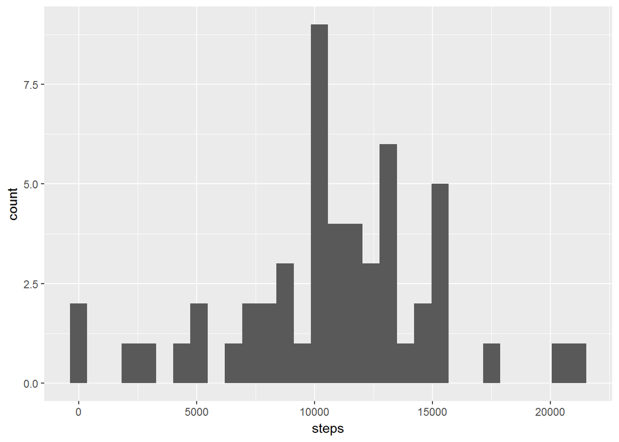

```r
    #Answer mean = 10766/day
    #Answer median = 10765

library(ggplot2)
qplot(steps, data = byday)
```

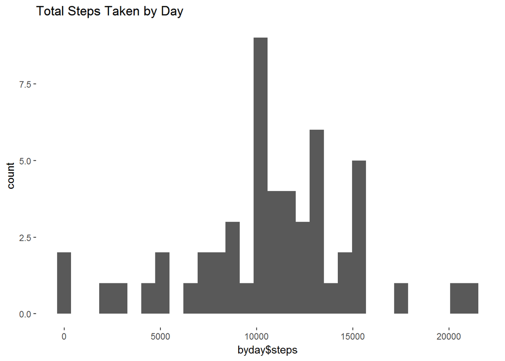

```r
ActbyDay <- ggplot(byday, aes(byday$steps)) + geom_histogram()
ActbyDay  <- ActbyDay + ggtitle("Total Steps Taken by Day")+
    theme(panel.background = element_blank(),
          legend.key=element_blank())
print(ActbyDay)
```

```r
ActivityInterval <- group_by(FinalActivity, interval)
ActivityInterval <- summarize(ActivityInterval, steps=mean(steps))
str(ActivityInterval)
```

```
## Classes 'tbl_df', 'tbl' and 'data.frame':    288 obs. of  2 variables:
##  $ interval: int  0 5 10 15 20 25 30 35 40 45 ...
##  $ steps   : num  1.717 0.3396 0.1321 0.1509 0.0755 ...
##  - attr(*, "na.action")=Class 'omit'  Named int [1:2304] 1 2 3 4 5 6 7 8 9 10 ...
##   .. ..- attr(*, "names")= chr [1:2304] "1" "2" "3" "4" ...
```

```r
summary(ActivityInterval)
```

```
##     interval          steps
##  Min.   :   0.0   Min.   :  0.000
##  1st Qu.: 588.8   1st Qu.:  2.486
##  Median :1177.5   Median : 34.113
##  Mean   :1177.5   Mean   : 37.383
##  3rd Qu.:1766.2   3rd Qu.: 52.835
##  Max.   :2355.0   Max.   :206.170
```

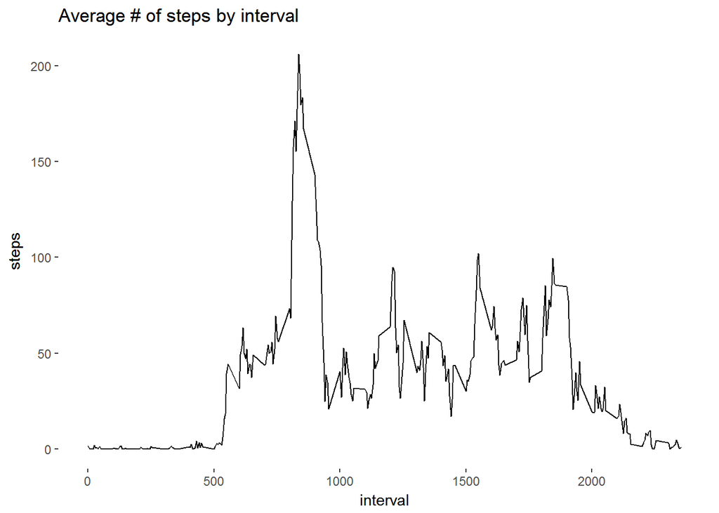

```r
ggplot(ActivityInterval, aes(interval, steps)) + geom_line() +
    ggtitle("Average # of steps by interval") +
    theme(panel.background = element_blank(),
          legend.key=element_blank())
```

```r
    ##looking at plot we can see max stepos ins in the interval between 500 and 1000

ActivityInterval[ActivityInterval$steps==max(ActivityInterval$steps),]
```

```
## # A tibble: 1 x 2
##   interval    steps
##      <int>    <dbl>
## 1      835 206.1698
```

```r
    ##Answer = interval 835 w/206 steps
```

## Imputing missing values

Note that there are a number of days/intervals where there are missing values (coded as NA). The presence of missing days may introduce bias into some calculations or summaries of the data.

[output not shown]

```r
    pbyday <- group_by(ActivityPlus, date)
    pbyday <- summarize(pbyday, steps=sum(steps))
    summary(pbyday)
```

```
##          date        steps
##  2012-10-01: 1   Min.   :   41
##  2012-10-02: 1   1st Qu.: 9819
##  2012-10-03: 1   Median :10766
##  2012-10-04: 1   Mean   :10766
##  2012-10-05: 1   3rd Qu.:12811
##  2012-10-06: 1   Max.   :21194
##  (Other)   :55
```

[figure not shown]

[output not shown]

```r
    ActPlusbyDay <- ggplot(pbyday, aes(pbyday$steps)) + geom_histogram()
    ActPlusbyDay <- ActPlusbyDay + ggtitle("Total Steps Taken by Day")+
                    theme(panel.background = element_blank(),
                    legend.key=element_blank())
    print(ActPlusbyDay)
```

For this part the weekdays() function may be of some help here. Use the dataset with the filled-in missing values for this part.

[output not shown]

Note: used coding strategy as outlined here. https://rstudio-pubs-static.s3.amazonaws.com/208975_082753bcf8164a08b288d6b28915ce20.html

Note: the code below works, but there is sa kntr error message weekdays <- ActivityPlus[ActivityPlus$weekend==“Weekday”,] weekend <- ActivityPlus[ActivityPlus$weekend==“Weekend”,] head(weekdays) head(weekend)